# Seminar 9

# Gene clustering

## A smaller dataset

Let's first do DE analysis using limma and select top 972 genes across different developmental stages:

```r
# DE analysis
model.mat <- model.matrix(~devStage, prDesc)

pr.fit <- lmFit(prDat, model.mat)
ebayes.fit <- eBayes(pr.fit)

# this list is sorted by adj.P.Val
top.genes <- topTable(ebayes.fit, number = 972, coef = grep("devStage", colnames(coef(ebayes.fit))))
head(top.genes)
```

```
##                    ID devStageP2 devStageP6 devStageP10 devStage4_weeks
## 1440645_at 1440645_at     0.3040    0.24339      0.8343           3.633
## 1421084_at 1421084_at     0.6697    3.49855      5.1652           5.506
## 1451590_at 1451590_at     0.4569    2.12916      3.5209           4.920
## 1428680_at 1428680_at     0.2265    0.21227      1.0350           3.072
## 1450215_at 1450215_at     1.5362    3.43618      4.8949           5.504
## 1416041_at 1416041_at    -0.1085    0.09961      0.8187           4.425
##            AveExpr     F   P.Value adj.P.Val
## 1440645_at   6.569 245.1 5.085e-26 1.523e-21
## 1421084_at  10.023 168.8 3.605e-23 5.398e-19
## 1451590_at   9.124 157.2 1.243e-22 1.240e-18
## 1428680_at   8.066 140.9 8.274e-22 6.195e-18
## 1450215_at   9.201 122.4 9.280e-21 5.558e-17
## 1416041_at   9.325 111.4 4.631e-20 2.311e-16
```

```r
# a sanity check
sum(top.genes$adj.P.Val < 1e-05) == 972
```

```
## [1] TRUE
```

```r
# filter it out
topDat <- sprDat[row.names(sprDat) %in% top.genes$ID, ]
nrow(topDat)
```

```
## [1] 972
```

### Hierarchical

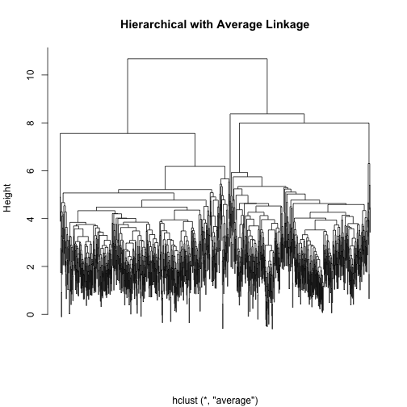

```r
geneC.dis <- dist(topDat, method = "euclidean")
geneC.hc.a <- hclust(geneC.dis, method = "average")
plot(geneC.hc.a, labels = FALSE, main = "Hierarchical with Average Linkage",
    xlab = "")
```

### Partitioning

In this plot, we're doing something wierd! We're plotting dimensions in the x-axis. So **samples** are the ticks/points in the horizontal axis and the y-value would be their magnitude of the point in that dimension.

Make a list for each sample name, joining all the columns in prDesc:

```r
l <- aaply(as.matrix(prDesc), 1, function(x) paste(x[3], x[4], x[2], sep = "_"))

# is the order right?
all(prDesc[, 1] == colnames(topDat))
```

```
## [1] TRUE
```

Now use l as the labels in the backbone plot:

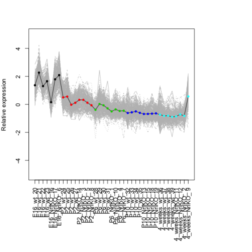

```r
k <- 5
kmeans.genes <- kmeans(topDat, centers = k)

# choose which cluster we want
clusterNum <- 1

par(mar = c(10, 4, 4, 8))
# the wierd thing. Dimensions as ticks on the x-axis
plot(kmeans.genes$centers[clusterNum, ], type = "n", ylim = c(-5, 5), xaxt = "n",
    xlab = "", ylab = "Relative expression")


axis(1, at = 1:39, labels = l, col.axis = "black", las = 2)

# Plot the expression of all the genes in the selected cluster in grey.
matlines(y = t(topDat[kmeans.genes$cluster == clusterNum, ]), col = "grey")

# Add the cluster center. This is last so it isn't underneath the members
points(kmeans.genes$centers[clusterNum, ], type = "l")

# Optional: colored points to show which development stage the samples are
# from.
points(kmeans.genes$centers[clusterNum, ], col = prDesc$devStage, pch = 20)
```

## Heatmaps and dendograms on top of them:

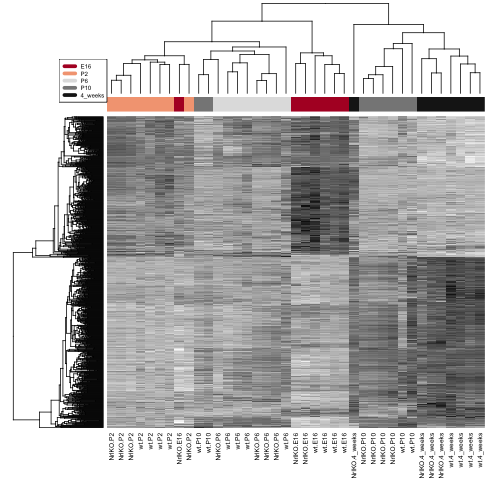

```r
devStageCols <- brewer.pal(11, "RdGy")[c(2, 4, 7, 9, 11)]
heatmap(as.matrix(topDat), col = jGraysFun(256), hclustfun = function(x) hclust(x,
    method = "average"), labCol = prDesc$grp, labRow = NA, margin = c(8, 1),
    scale = "none", ColSideColor = devStageCols[unclass(prDesc$devStage)])
legend("topleft", levels(prDesc$devStage), col = devStageCols, lty = 1, lwd = 5,
    cex = 0.5)
```

# Redefining the attributes

```r
# stack probe data tall and skinny
annoTopDat <- stack(as.data.frame(topDat))

`?`(stack)


# add probeset ID as variable
annoTopDat$probeset <- rownames(topDat)

head(annoTopDat)
```

```
##    values       ind     probeset
## 1 -0.1351 Sample_20   1415711_at
## 2  1.2034 Sample_20 1415716_a_at
## 3 -0.2987 Sample_20   1415802_at
## 4  1.2596 Sample_20   1415810_at
## 5  0.9569 Sample_20 1415849_s_at
## 6  1.1586 Sample_20 1415876_a_at
```

```r
# perhaps could have done a melt? Yeah, we'll go with melt
exp <- melt(topDat)

## get info on gType and devStage, then average over reps within devStage
## it's basically a table join
annoTopDat <- merge(annoTopDat, prDesc, by.x = "ind", by.y = "sidChar")

# basically, for each probeset, return the average for each dev stage
devStageAvg <- ddply(annoTopDat, ~probeset, function(x) {
    avgByDevStage <- aggregate(values ~ devStage, x, mean)$values
    names(avgByDevStage) <- levels(x$devStage)
    avgByDevStage
})

## put probset info back into rownames
rownames(devStageAvg) <- devStageAvg$probeset
devStageAvg$probeset <- NULL
str(devStageAvg)
```

```
## 'data.frame':    972 obs. of  5 variables:
##  $ E16    : num  -0.628 1.235 -0.419 1.401 0.855 ...
##  $ P2     : num  -1.041 0.7 -0.918 0.737 0.74 ...
##  $ P6     : num  -0.214 -0.26 -0.744 -0.66 0.34 ...
##  $ P10    : num  0.722 -0.683 0.553 -0.779 -0.363 ...
##  $ 4_weeks: num  1.083 -0.838 1.475 -0.523 -1.464 ...
```

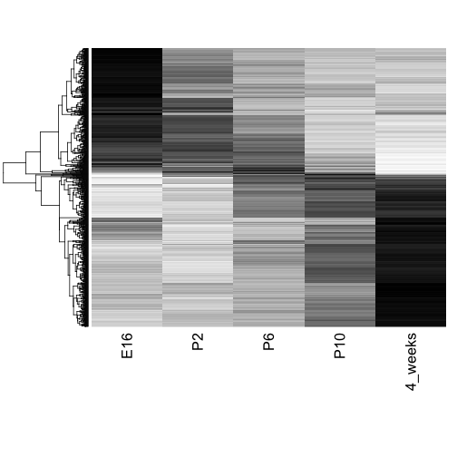

```r
heatmap(as.matrix(devStageAvg), Colv = NA, col = jGraysFun(256), hclustfun = function(x) hclust(x,
    method = "average"), labCol = colnames(devStageAvg), labRow = NA, margin = c(8,
    1))
```

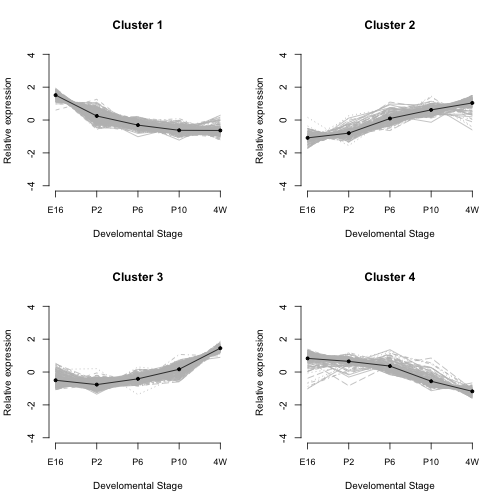

```r
k <- 4
geneDS.km <- kmeans(devStageAvg, centers = k, nstart = 50)
clust.centers <- geneDS.km$centers

# Look at all clusters
op <- par(mfrow = c(2, 2))
for (clusterNum in 1:4) {
    # Set up the axes without plotting; ylim set based on trial run.
    plot(clust.centers[clusterNum, ], ylim = c(-4, 4), type = "n", xlab = "Develomental Stage",
        ylab = "Relative expression", axes = F, main = paste("Cluster", clusterNum,
            sep = " "))
    axis(2)
    axis(1, 1:5, c(colnames(clust.centers)[1:4], "4W"), cex.axis = 0.9)

    # Plot the expression of all the genes in the selected cluster in grey.
    matlines(y = t(devStageAvg[geneDS.km$cluster == clusterNum, ]), col = "grey")

    # Add the cluster center. This is last so it isn't underneath the members
    points(clust.centers[clusterNum, ], type = "l")

    # Optional: points to show development stages.
    points(clust.centers[clusterNum, ], pch = 20)
}
```

Comparing cluster centers (centroids):

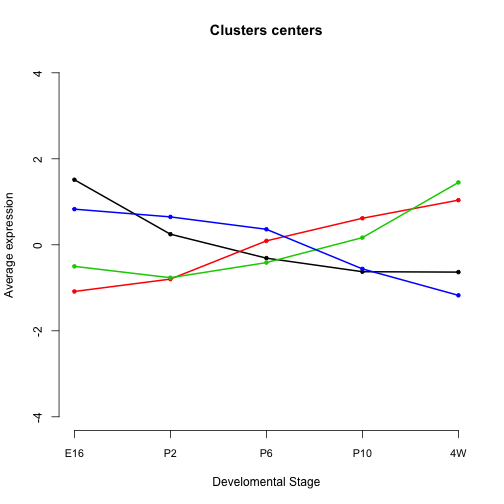

```r
plot(clust.centers[clusterNum, ], ylim = c(-4, 4), type = "n", xlab = "Develomental Stage",
    ylab = "Average expression", axes = FALSE, main = "Clusters centers")
axis(2)
axis(1, 1:5, c(colnames(clust.centers)[1:4], "4W"), cex.axis = 0.9)

for (clusterNum in 1:4) {
    points(clust.centers[clusterNum, ], type = "l", col = clusterNum, lwd = 2)
    points(clust.centers[clusterNum, ], col = clusterNum, pch = 20)
}
```

Cloud! And some experimenting with formula. Turns on that * and + have the same effect here.

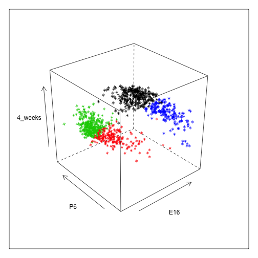

```r
cloud(devStageAvg[, "E16"] ~ devStageAvg[, "P6"] * devStageAvg[, "4_weeks"],
    col = geneDS.km$clust, xlab = "E16", ylab = "P6", zlab = "4_weeks", main = "")
```

[figure not shown]

```r
t = rep(2, 100)
t3 = seq(100)
t1 = 1:100
t2 = 100:1
cloud(t ~ t1 * t2)
```

[figure not shown]

```r
wireframe(t ~ t1 * t2)
```

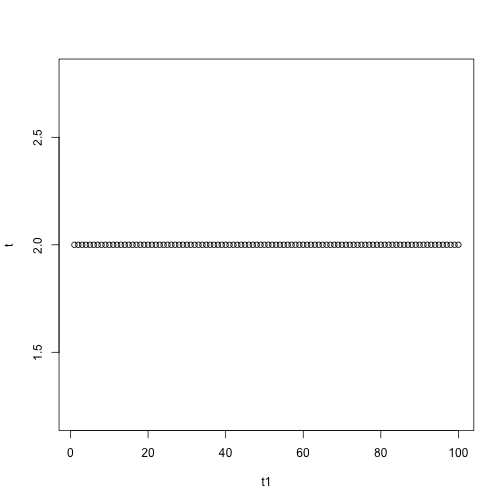

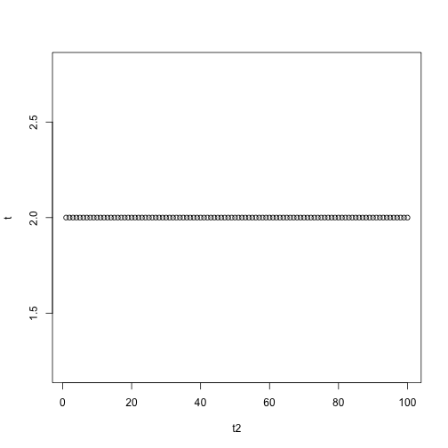

```r
plot(t ~ t1 + t2)
```

# Statistical measures to evaluate clusters

Let's give pvclust a try! The link [here](http://www.is.titech.ac.jp/%7Eshimo/prog/pvclust/) notes that it can be used in parallel as well.

We're using both p-value calculation methods here, AU and BP. AU (Approximately Unbiased) was recommened in the package's homepage.

```r
pvc <- pvclust(topDat, nboot = 100)
```

```
## Bootstrap (r = 0.5)... Done.
## Bootstrap (r = 0.6)... Done.
## Bootstrap (r = 0.7)... Done.
## Bootstrap (r = 0.8)... Done.
## Bootstrap (r = 0.9)... Done.
## Bootstrap (r = 1.0)... Done.
## Bootstrap (r = 1.1)... Done.
## Bootstrap (r = 1.2)... Done.
## Bootstrap (r = 1.3)... Done.
## Bootstrap (r = 1.4)... Done.
```

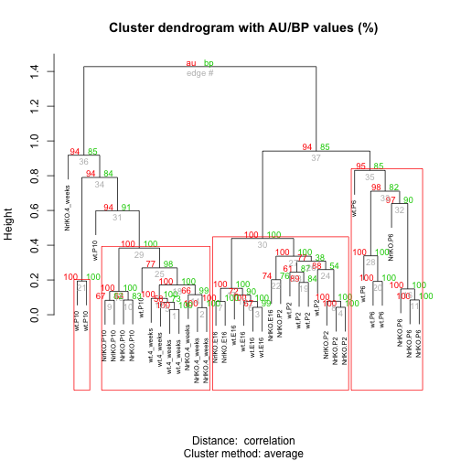

```r
plot(pvc, labels = prDesc$grp, cex = 0.6)
pvrect(pvc, alpha = 0.95)
```

# PCA (principal components analysis)

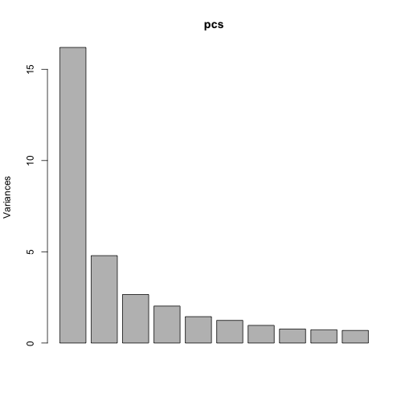

```r
pcs <- prcomp(sprDat, center = F, scale = F)

# scree plot
plot(pcs)
```

There's an interesting correlation between sidNumber and PC2!

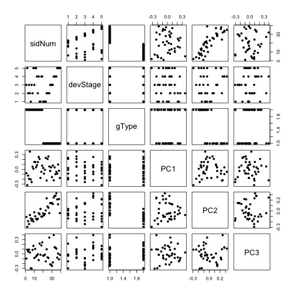

```r
# append the rotations for the first 10 PCs to the phenodata
prinComp <- cbind(prDesc, pcs$rotation[prDesc$sidNum, 1:10])

# scatter plot showing us how the first few PCs relate to covariates
plot(prinComp[, c("sidNum", "devStage", "gType", "PC1", "PC2", "PC3")], pch = 19,
    cex = 0.8)
```

Some experiments: For each instance, i.e., each sample, plot the two variables.

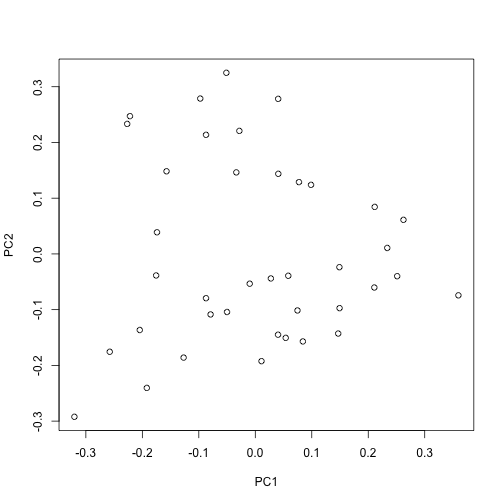

```r
r <- pcs$rotation
plot(PC2 ~ PC1, r)
```

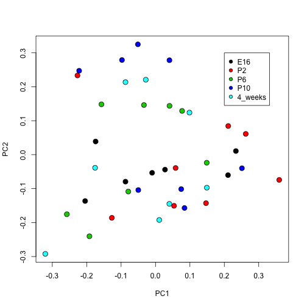

```r
# plot data on first two PCs, colored by development stage
plot(prinComp[, c("PC1", "PC2")], bg = prDesc$devStage, pch = 21, cex = 1.5)
legend(list(x = 0.2, y = 0.3), as.character(levels(prDesc$devStage)), pch = 21,
    pt.bg = c(1, 2, 3, 4, 5))
```